# Assignment 4: Ensemble Methods

Juan D. Gelvez

## Setup

```r
rm(list=ls())
library(mlbench)
library(foreach)
library(caret)
library(rpart)
library(randomForest)
library(e1071)
library(class)
library(xgboost)
```

## Data

In this notebook, we use the Boston Housing data set (again). “This dataset contains information collected by the U.S Census Service concerning housing in the area of Boston Mass. It was obtained from the StatLib archive (http://lib.stat.cmu.edu/datasets/boston), and has been used extensively throughout the literature to benchmark algorithms.”

Source: https://www.cs.toronto.edu/~delve/data/boston/bostonDetail.html

```r
data(BostonHousing2)
names(BostonHousing2)
```

```
##  [1] "town"    "tract"   "lon"     "lat"     "medv"    "cmedv"   "crim"
##  [8] "zn"      "indus"   "chas"    "nox"     "rm"      "age"     "dis"
## [15] "rad"     "tax"     "ptratio" "b"       "lstat"
```

First, we drop some variables that we will not use in the next sections.

```r
BostonHousing2$town <- NULL
BostonHousing2$tract <- NULL
BostonHousing2$cmedv <- NULL
```

Next, we start by splitting the data into a train and test set.

```r
set.seed(1293)
train <- sample(1:nrow(BostonHousing2), 0.8*nrow(BostonHousing2))
boston_train <- BostonHousing2[train,]
boston_test <- BostonHousing2[-train,]
```

#### 1) Bagging with Trees

**a) Build a Bagging model using a `foreach` loop. Use the `maxdepth` control option to grow very small trees. These don’t have to be stumps, but should not be much larger than a few splits.**

```r
ctrl <- rpart.control(maxdepth = 3)
# Bagging model using foreach
predictions <- foreach(m = 1:100, .combine = cbind) %do% {
  index <- sample(1:nrow(boston_train), replace = TRUE)
  train_sample <- boston_train[index, ]
  fit <- rpart(medv ~ ., data = train_sample, method = "anova", control = ctrl)
  predict(fit, newdata = boston_test)
}

# Calculate the mean predictions
mean_predictions <- rowMeans(predictions)

actual <- boston_test$medv
predicted <- mean_predictions

# RMSE
postResample(predicted, actual)
```

```
##      RMSE  Rsquared       MAE
## 3.8048378 0.7976314 2.5544164
```

**b) Plot the last tree of the ensemble to check tree size.**

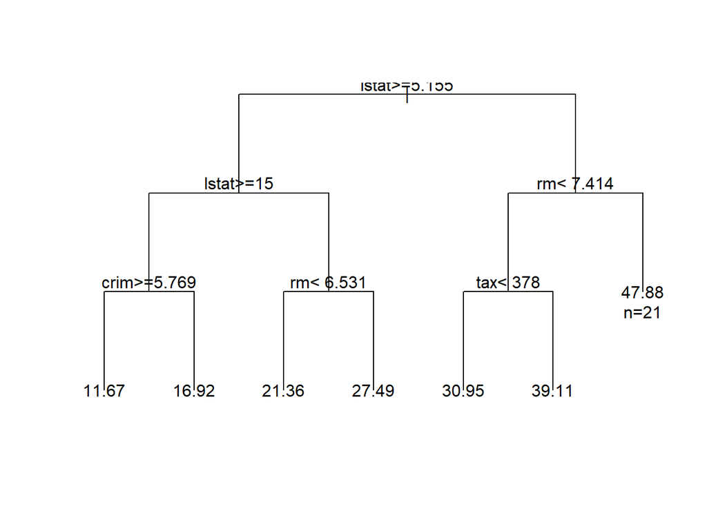

```r
plot(fit, uniform = TRUE)
text(fit, use.n = TRUE)
```

**c) Compare the performance of the last tree in the bagging process with the ensemble. That is, look at the performance of the last tree in the loop and compare it with the performance in the overall averaged bagging model.**

```r
last_tree_predictions <- predict(fit, newdata = boston_test) # Predictions from the last tree
last_tree_performance <- postResample(last_tree_predictions, boston_test$medv) # Evaluate the last tree's performance
#ensemb performance
ensemble_performance <- postResample(mean_predictions, boston_test$medv)


cat("Last Tree RMSE:", last_tree_performance[1], "\n")
```

```
## Last Tree RMSE: 4.060449
```

```r
cat("Ensemble RMSE:", ensemble_performance[1], "\n")
```

```
## Ensemble RMSE: 3.804838
```

#### 2) Bagging with Bigger Trees

**a) In the first loop we’ve grown small trees. Now, build a new loop and adjust `maxdepth` such that very large trees are grown as individual pieces of the Bagging model.**

```r
ctrl2 <- rpart.control(maxdepth = 30) # Example of a large depth, or simply omit this parameter

predictions_large_trees <- foreach(m = 1:100, .combine = cbind) %do% {
  index <- sample(1:nrow(boston_train), replace = TRUE)
  train_sample <- boston_train[index, ]
  fit_large <- rpart(medv ~ ., data = train_sample, method = "anova", control = ctrl2)
  predict(fit_large, newdata = boston_test)
}

mean_predictions_large_trees <- rowMeans(predictions_large_trees)
predicted_large_trees <- mean_predictions_large_trees

performance_large_trees <- postResample(predicted_large_trees, actual)
cat("RMSE for Bagging with Large Trees:", performance_large_trees[1], "\n")
```

```
## RMSE for Bagging with Large Trees: 3.645943
```

```r
#notice that the RMSE is smaller than the previous Bagging Ensemble
```

**b) Confirm that these trees are larger by plotting the last tree.**

It is bigger compared to the previous one:

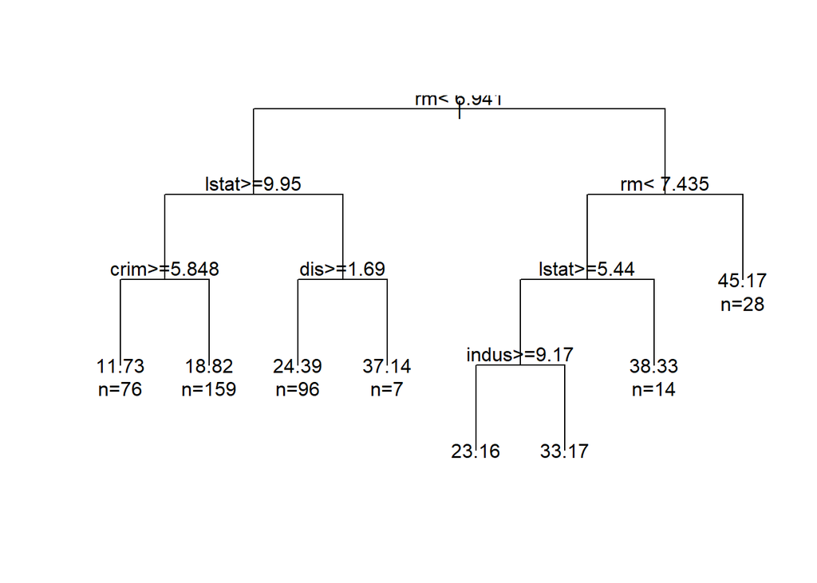

```r
plot(fit_large, uniform = TRUE)
text(fit_large, use.n = TRUE)
```

**c) Show how this ensemble model performs.**

```r
last_tree_predictions_large <- predict(fit_large, newdata = boston_test) # Predictions from the last tree
last_tree_performance_large <- postResample(last_tree_predictions_large, boston_test$medv) # Evaluate the last tree's performance
#ensemb performance
ensemble_performance_large <- postResample(mean_predictions_large_trees, boston_test$medv)


cat("Last Tree RMSE Large:", last_tree_performance_large[1], "\n")
```

```
## Last Tree RMSE Large: 4.610384
```

```r
cat("Ensemble RMSE Large:", ensemble_performance_large[1], "\n")
```

```
## Ensemble RMSE Large: 3.645943
```

#### 3) Building a Boosting Model with XGBoost

**a) Now let’s try using a boosting model using trees as the base learner. Here, we will use the XGBoost model. First, set up the `trainControl` parameters.**

```r
# Setting 5-fold
ctrl <- trainControl(method = "cv",
                     number = 5,
                     savePredictions = "final",
                     verboseIter = TRUE)
```

**b) Next, set up the tuning parameters by creating a grid of parameters to try.**

```r
tuneGrid <- expand.grid(nrounds = c(10, 20),
                        max_depth = c(3, 6, 9),
                        eta = c(0.01, 0.1),
                        gamma = c(0, 0.1),
                        colsample_bytree = c(0.5, 0.75),
                        min_child_weight = c(1, 3),
                        subsample = c(0.5, 0.75))
```

**c) Using CV to tune, fit an XGBoost model.**

```r
xgbModel <- train(medv ~ .,
                  data = boston_train,
                  method = "xgbTree",
                  trControl = ctrl,
                  tuneGrid = tuneGrid,
                  metric = "RMSE")
```

[output not shown]

[output cut: 426 more lines]

[output not shown]

**d) Compare the performance of the boosting model with the models run previously in this assignment. How does it compare?**

```r
cat("Ensemble RMSE Small:", ensemble_performance[1], "\n") #smalltree
```

```
## Ensemble RMSE Small: 3.804838
```

```r
cat("Ensemble RMSE Large:", ensemble_performance_large[1], "\n") #bigtree
```

```
## Ensemble RMSE Large: 3.645943
```

```r
pred_xgb <- predict(xgbModel, newdata = boston_test)
results_xgb <- postResample(pred_xgb, boston_test$medv)
results_xgb
```

```
##      RMSE  Rsquared       MAE
## 4.2631737 0.8813542 3.2315310
```

The results are as follows, suggesting better performance of larger trees than small trees or XGBModels.

#### 4) Comparing Models with `caretList`

**a) Use `caretList` to run a Bagging model, a Random Forest model, and an XGBoost model using the same CV splits with 5-fold CV. Plot the performance by RMSE. How do the models compare?**

*Hint: You can use `treebag`, `ranger`, and `xgbTree` for the models.*

```r
library(caret)
library(caretEnsemble)
?caretList
```

```
## starting httpd help server ...
```

```
##  done
```

```r
ctrl <- trainControl(method = "cv",
                     number = 5,
                     savePredictions = "final",
                     allowParallel = TRUE)

models <- caretList(medv ~ .,
                    data = boston_train,
                    trControl = ctrl,
                    methodList = c("treebag", "ranger", "xgbTree"))
```

[output not shown]

[output cut: 305 more lines]

[output not shown]

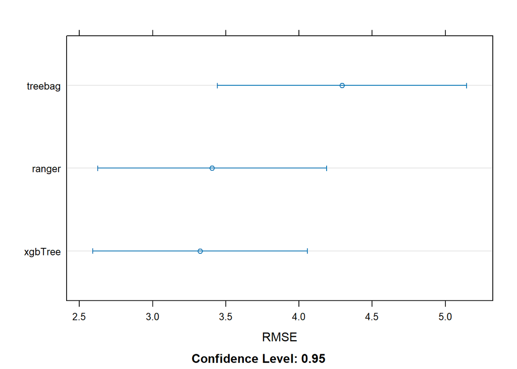

```r
results <- resamples(models)
dotplot(results, metric = "RMSE")
```

Lower average RMSE values indicate better average performance across the cross-validation folds. The lines represent the confidence intervals around the average RMSE (here at a 95% confidence level), indicating the range within which we can be confident that the true mean RMSE lies.

The xgbTree model appears to be the best performer in terms of both average RMSE and consistency of performance across CV folds.However it seems that is not statistically different from the other two. It is important to also consider other metrics like MAE